# Program Summary - Program 5

### Program Summary - Program 5

### Execution Environment

| Author: | u59814750 |
| --- | --- |
| File: |  |
| SAS Platform: | Linux LIN X64 3.10.0-1062.9.1.el7.x86_64 |
| SAS Host: | ODAWS01-EUW1.ODA.SAS.COM |
| SAS Version: | 9.04.01M6P11072018 |
| SAS Locale: | tr_TR |
| Submission Time: | 30.01.2022 19:30:34 |
| Browser Host: | 178.233.117.30 |
| User Agent: | Mozilla/5.0 (Macintosh; Intel Mac OS X 10_15_7) AppleWebKit/537.36 (KHTML, like Gecko) Chrome/97.0.4692.99 Safari/537.36 |
| Application Server: | ODAMID00-EUW1.ODA.SAS.COM |

### Code: Program 5

/* Generated Code (IMPORT) */

/* Source File: breast_canser_data.csv */

/* Source Path: /home/u59814750/ecem_breast_canser_data */

/* Code generated on: 30.01.2022 18:50 */

%web_drop_table(WORK.IMPORT1);

FILENAME REFFILE '/home/u59814750/ecem_breast_canser_data/breast_canser_data.csv';

PROC IMPORT DATAFILE=REFFILE

DBMS=CSV

OUT=WORK.IMPORT1;

GETNAMES=YES;

RUN;

PROC CONTENTS DATA=WORK.IMPORT1; RUN;

%web_open_table(WORK.IMPORT1);

/*Hiyerarşik Kümeleme Analizi*/

proc cluster data=IMPORT1 method=centroid outtree=centroid plots(maxpoints=1000) ;

ID HER1_status;

VAR Protein1 Protein2 Protein3 Protein4;

run;

proc cluster data=IMPORT1 method=centroid out=tree plots(maxpoints=1000);

ID HER1_status;

VAR Protein1 Protein2 Protein3 Protein4;

/*K-MEANS KÜMELEME ANALİZİ*/

proc fastclus data=IMPORT1 maxiter=10 maxclusters=3 list distance out=clust;

var Protein1 Protein2 Protein3 Protein4;

id HER1_status;

run;

/*Değişkenlerin kümelemede anlamlı olup olmadığına bakıyoruz */

proc glm data=clust;

class cluster;

model Protein1=cluster;

run;

proc glm data=clust;

class cluster;

model Protein2=cluster;

run;

proc glm data=clust;

class cluster;

model Protein3=cluster;

run;

proc glm data=clust;

class cluster;

model Protein4=cluster;

run;

### Log: Program 5

Warnings (2)

Notes (20)

[output not shown]

### Results: Program 5

The CONTENTS Procedure

| Data Set Name | WORK.IMPORT1 | Observations | 321 |
| --- | --- | --- | --- |
| Member Type | DATA | Variables | 13 |
| Engine | V9 | Indexes | 0 |
| Created | 30.01.2022 19:30:32 | Observation Length | 136 |
| Last Modified | 30.01.2022 19:30:32 | Deleted Observations | 0 |
| Protection |  | Compressed | NO |
| Data Set Type |  | Sorted | NO |
| Label |  |  |  |
| Data Representation | SOLARIS_X86_64, LINUX_X86_64, ALPHA_TRU64, LINUX_IA64 |  |  |
| Encoding | utf-8 Unicode (UTF-8) |  |  |

[output not shown]

| Alphabetic List of Variables and Attributes # | Alphabetic List of Variables and Attributes Variable | Alphabetic List of Variables and Attributes Type | Alphabetic List of Variables and Attributes Len | Alphabetic List of Variables and Attributes Format | Alphabetic List of Variables and Attributes Informat |
| --- | --- | --- | --- | --- | --- |
| 1 | Age | Num | 8 | BEST12. | BEST32. |
| 9 | ER_status | Char | 8 | $8. | $8. |
| 2 | Gender | Char | 6 | $6. | $6. |
| 11 | HER1_status | Num | 8 | BEST12. | BEST32. |
| 8 | Histology | Char | 30 | $30. | $30. |
| 10 | PR_status | Char | 8 | $8. | $8. |
| 13 | Patient_Status | Char | 5 | $5. | $5. |
| 3 | Protein1 | Num | 8 | BEST12. | BEST32. |
| 4 | Protein2 | Num | 8 | BEST12. | BEST32. |
| 5 | Protein3 | Num | 8 | BEST12. | BEST32. |
| 6 | Protein4 | Num | 8 | BEST12. | BEST32. |
| 12 | Surgery_type | Char | 27 | $27. | $27. |
| 7 | Tumour_Stage | Char | 3 | $3. | $3. |

The CLUSTER Procedure

Centroid Hierarchical Cluster Analysis

| Eigenvalues of the Covariance Matrix | Eigenvalues of the Covariance Matrix Eigenvalue | Eigenvalues of the Covariance Matrix Difference | Eigenvalues of the Covariance Matrix Proportion | Eigenvalues of the Covariance Matrix Cumulative |
| --- | --- | --- | --- | --- |
| 1 | 0.93940868 | 0.50482806 | 0.5052 | 0.5052 |
| 2 | 0.43458062 | 0.17581674 | 0.2337 | 0.7389 |
| 3 | 0.25876388 | 0.03199571 | 0.1392 | 0.8781 |
| 4 | 0.22676817 |  | 0.1219 | 1.0000 |

| Root-Mean-Square Total-Sample Standard Deviation | 0.681821 |
| --- | --- |

| Root-Mean-Square Distance Between Observations | 1.928482 |
| --- | --- |

| Cluster History Number of Clusters | Cluster History Clusters Joined | Cluster History Clusters Joined | Cluster History Freq | Cluster History Norm Centroid Distance | Cluster History Tie |
| --- | --- | --- | --- | --- | --- |
| 320 | 1 | 0 | 2 | 0.0561 |  |
| 319 | 0 | 0 | 2 | 0.0659 |  |
| 318 | 0 | 0 | 2 | 0.07 |  |
| 317 | 0 | 0 | 2 | 0.0797 |  |
| 316 | 0 | 0 | 2 | 0.0855 |  |
| 315 | 1 | 0 | 2 | 0.0856 |  |
| 314 | 0 | 0 | 2 | 0.0859 |  |
| 313 | 1 | 0 | 2 | 0.0862 |  |
| 312 | 0 | 1 | 2 | 0.0944 |  |
| 311 | 0 | 0 | 2 | 0.0948 |  |
| 310 | 0 | 0 | 2 | 0.0964 |  |
| 309 | 0 | 0 | 2 | 0.0974 |  |
| 308 | 0 | 0 | 2 | 0.102 |  |
| 307 | 0 | 0 | 2 | 0.1038 |  |
| 306 | 0 | 0 | 2 | 0.105 |  |
| 305 | 0 | 0 | 2 | 0.1101 |  |
| 304 | CL318 | 0 | 3 | 0.1129 |  |
| 303 | 0 | 0 | 2 | 0.1199 |  |
| 302 | 0 | 0 | 2 | 0.12 |  |
| 301 | 0 | 0 | 2 | 0.1201 |  |
| 300 | 0 | 0 | 2 | 0.1203 |  |
| 299 | 0 | 0 | 2 | 0.1204 |  |
| 298 | 0 | 0 | 2 | 0.1208 |  |
| 297 | 0 | 0 | 2 | 0.1223 |  |
| 296 | 1 | 0 | 2 | 0.1259 |  |
| 295 | 1 | 0 | 2 | 0.1269 |  |
| 294 | 1 | 0 | 2 | 0.1277 |  |
| 293 | 0 | 1 | 2 | 0.1281 |  |
| 292 | 0 | 0 | 2 | 0.1289 |  |
| 291 | 0 | 0 | 2 | 0.1309 |  |

[output cut: 290 more lines]

[figure not shown]

The CLUSTER Procedure

Centroid Hierarchical Cluster Analysis

| Eigenvalues of the Covariance Matrix | Eigenvalues of the Covariance Matrix Eigenvalue | Eigenvalues of the Covariance Matrix Difference | Eigenvalues of the Covariance Matrix Proportion | Eigenvalues of the Covariance Matrix Cumulative |
| --- | --- | --- | --- | --- |
| 1 | 0.93940868 | 0.50482806 | 0.5052 | 0.5052 |
| 2 | 0.43458062 | 0.17581674 | 0.2337 | 0.7389 |
| 3 | 0.25876388 | 0.03199571 | 0.1392 | 0.8781 |
| 4 | 0.22676817 |  | 0.1219 | 1.0000 |

| Root-Mean-Square Total-Sample Standard Deviation | 0.681821 |
| --- | --- |

| Root-Mean-Square Distance Between Observations | 1.928482 |
| --- | --- |

| Cluster History Number of Clusters | Cluster History Clusters Joined | Cluster History Clusters Joined | Cluster History Freq | Cluster History Norm Centroid Distance | Cluster History Tie |
| --- | --- | --- | --- | --- | --- |
| 320 | 1 | 0 | 2 | 0.0561 |  |
| 319 | 0 | 0 | 2 | 0.0659 |  |
| 318 | 0 | 0 | 2 | 0.07 |  |
| 317 | 0 | 0 | 2 | 0.0797 |  |
| 316 | 0 | 0 | 2 | 0.0855 |  |
| 315 | 1 | 0 | 2 | 0.0856 |  |
| 314 | 0 | 0 | 2 | 0.0859 |  |
| 313 | 1 | 0 | 2 | 0.0862 |  |
| 312 | 0 | 1 | 2 | 0.0944 |  |
| 311 | 0 | 0 | 2 | 0.0948 |  |
| 310 | 0 | 0 | 2 | 0.0964 |  |
| 309 | 0 | 0 | 2 | 0.0974 |  |
| 308 | 0 | 0 | 2 | 0.102 |  |
| 307 | 0 | 0 | 2 | 0.1038 |  |
| 306 | 0 | 0 | 2 | 0.105 |  |
| 305 | 0 | 0 | 2 | 0.1101 |  |
| 304 | CL318 | 0 | 3 | 0.1129 |  |
| 303 | 0 | 0 | 2 | 0.1199 |  |
| 302 | 0 | 0 | 2 | 0.12 |  |
| 301 | 0 | 0 | 2 | 0.1201 |  |
| 300 | 0 | 0 | 2 | 0.1203 |  |
| 299 | 0 | 0 | 2 | 0.1204 |  |
| 298 | 0 | 0 | 2 | 0.1208 |  |
| 297 | 0 | 0 | 2 | 0.1223 |  |
| 296 | 1 | 0 | 2 | 0.1259 |  |
| 295 | 1 | 0 | 2 | 0.1269 |  |
| 294 | 1 | 0 | 2 | 0.1277 |  |
| 293 | 0 | 1 | 2 | 0.1281 |  |
| 292 | 0 | 0 | 2 | 0.1289 |  |
| 291 | 0 | 0 | 2 | 0.1309 |  |

[output cut: 290 more lines]

[figure not shown]

The FASTCLUS Procedure

Replace=FULL Radius=0 Maxclusters=3 Maxiter=10 Converge=0.02

| Initial Seeds Cluster | Initial Seeds Protein1 | Initial Seeds Protein2 | Initial Seeds Protein3 | Initial Seeds Protein4 |
| --- | --- | --- | --- | --- |
| 1 | -2.144600000 | -0.179460000 | -0.200330000 | -1.488800000 |
| 2 | 0.783210000 | -0.841400000 | 1.507000000 | 0.816290000 |
| 3 | 0.287080000 | 3.402200000 | -0.328500000 | 0.216190000 |

| Minimum Distance Between Initial Seeds = | 4.151946 |
| --- | --- |

| Iteration History Iteration | Iteration History Criterion | Iteration History Relative Change in Cluster Seeds 1 | Iteration History Relative Change in Cluster Seeds 2 | Iteration History Relative Change in Cluster Seeds 3 |
| --- | --- | --- | --- | --- |
| 1 | 1.0329 | 0.4589 | 0.4196 | 0.4272 |
| 2 | 0.5119 | 0.0298 | 0.0274 | 0.0147 |
| 3 | 0.5083 | 0.0281 | 0.0234 | 0.00361 |
| 4 | 0.5062 | 0.00987 | 0.0201 | 0.00732 |
| 5 | 0.5053 | 0.00767 | 0.0141 | 0.00301 |

| Convergence criterion is satisfied. |
| --- |

| Cluster Listing Obs | Cluster Listing HER1_status | Cluster Listing Cluster | Cluster Listing Distance from Seed |
| --- | --- | --- | --- |
| 1 | 0 | 2 | 0.6586 |
| 2 | 0 | 2 | 0.8676 |
| 3 | 0 | 3 | 0.5376 |
| 4 | 0 | 2 | 0.8813 |
| 5 | 0 | 3 | 0.9915 |
| 6 | 0 | 3 | 0.3791 |
| 7 | 0 | 3 | 0.3507 |
| 8 | 0 | 2 | 0.7846 |
| 9 | 1 | 3 | 0.7929 |
| 10 | 0 | 1 | 0.2835 |
| 11 | 0 | 1 | 0.4242 |
| 12 | 0 | 2 | 0.9384 |
| 13 | 0 | 1 | 1.5289 |
| 14 | 0 | 3 | 0.9126 |
| 15 | 0 | 3 | 1.0238 |
| 16 | 0 | 3 | 1.0018 |
| 17 | 0 | 3 | 0.6680 |
| 18 | 0 | 3 | 0.9694 |
| 19 | 0 | 3 | 0.6081 |
| 20 | 0 | 3 | 1.1841 |
| 21 | 0 | 2 | 0.7653 |
| 22 | 0 | 2 | 0.6262 |
| 23 | 0 | 3 | 0.5844 |
| 24 | 1 | 3 | 1.6507 |
| 25 | 0 | 2 | 1.2126 |
| 26 | 0 | 3 | 0.4061 |
| 27 | 0 | 3 | 0.8416 |
| 28 | 1 | 3 | 1.2780 |
| 29 | 0 | 3 | 0.8456 |
| 30 | 0 | 3 | 1.1081 |

[output cut: 291 more lines]

| Criterion Based on Final Seeds = | 0.5049 |
| --- | --- |

| Cluster Summary Cluster | Cluster Summary Frequency | Cluster Summary RMS Std Deviation | Cluster Summary Maximum Distance from Seed to Observation | Cluster Summary Radius Exceeded | Cluster Summary Nearest Cluster | Cluster Summary Distance Between Cluster Centroids |
| --- | --- | --- | --- | --- | --- | --- |
| 1 | 78 | 0.5099 | 2.1558 |  | 3 | 1.3511 |
| 2 | 72 | 0.5227 | 2.0879 |  | 1 | 1.4855 |
| 3 | 171 | 0.4994 | 2.2339 |  | 1 | 1.3511 |

| Statistics for Variables Variable | Statistics for Variables Total STD | Statistics for Variables Within STD | Statistics for Variables R-Square | Statistics for Variables RSQ/(1-RSQ) |
| --- | --- | --- | --- | --- |
| Protein1 | 0.54669 | 0.50711 | 0.144919 | 0.169479 |
| Protein2 | 0.90964 | 0.53152 | 0.660707 | 1.947308 |
| Protein3 | 0.58798 | 0.47112 | 0.362011 | 0.567424 |
| Protein4 | 0.62249 | 0.51720 | 0.313989 | 0.457704 |
| OVER-ALL | 0.68182 | 0.50723 | 0.450024 | 0.818261 |

| Pseudo F Statistic = | 130.10 |
| --- | --- |

| Approximate Expected Over-All R-Squared = | 0.45636 |
| --- | --- |

| Cubic Clustering Criterion = | -0.531 |
| --- | --- |

WARNING: The two values above are invalid for correlated variables.

| Cluster Means Cluster | Cluster Means Protein1 | Cluster Means Protein2 | Cluster Means Protein3 | Cluster Means Protein4 |
| --- | --- | --- | --- | --- |
| 1 | -0.332898542 | 0.639971745 | -0.344205205 | -0.605425949 |
| 2 | -0.130374069 | -0.213375847 | 0.559998328 | 0.181863278 |
| 3 | 0.157035868 | 1.589825322 | -0.253884681 | 0.216128516 |

| Cluster Standard Deviations Cluster | Cluster Standard Deviations Protein1 | Cluster Standard Deviations Protein2 | Cluster Standard Deviations Protein3 | Cluster Standard Deviations Protein4 |
| --- | --- | --- | --- | --- |
| 1 | 0.5348320894 | 0.5294447648 | 0.3838147419 | 0.5712693276 |
| 2 | 0.5664611290 | 0.4809978640 | 0.5327565545 | 0.5066437310 |
| 3 | 0.4663394715 | 0.5521469196 | 0.4794988226 | 0.4953350014 |

| Distance Between Cluster Centroids Nearest Cluster | Distance Between Cluster Centroids 1 | Distance Between Cluster Centroids 2 | Distance Between Cluster Centroids 3 |
| --- | --- | --- | --- |
| 1 | . | 1.485471854 | 1.351061464 |
| 2 | 1.485471854 | . | 1.999429565 |
| 3 | 1.351061464 | 1.999429565 | . |

The GLM Procedure

| Class Level Information Class | Class Level Information Levels | Class Level Information Values |
| --- | --- | --- |
| CLUSTER | 3 | 1 2 3 |

| Number of Observations Read | 321 |
| --- | --- |
| Number of Observations Used | 321 |

The GLM Procedure

Dependent Variable: Protein1

| Source | DF | Sum of Squares | Mean Square | F Value | Pr > F |
| --- | --- | --- | --- | --- | --- |
| Model | 2 | 13.85971818 | 6.92985909 | 26.95 | <.0001 |
| Error | 318 | 81.77817142 | 0.25716406 |  |  |
| Corrected Total | 320 | 95.63788960 |  |  |  |

| R-Square | Coeff Var | Root MSE | Protein1 Mean |
| --- | --- | --- | --- |
| 0.144919 | -1915.125 | 0.507113 | -0.026479 |

| Source | DF | Type I SS | Mean Square | F Value | Pr > F |
| --- | --- | --- | --- | --- | --- |
| CLUSTER | 2 | 13.85971818 | 6.92985909 | 26.95 | <.0001 |

| Source | DF | Type III SS | Mean Square | F Value | Pr > F |
| --- | --- | --- | --- | --- | --- |
| CLUSTER | 2 | 13.85971818 | 6.92985909 | 26.95 | <.0001 |

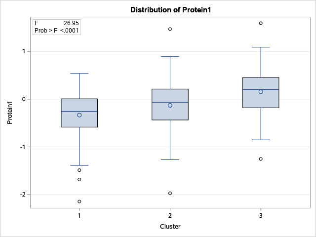

The GLM Procedure

| Class Level Information Class | Class Level Information Levels | Class Level Information Values |
| --- | --- | --- |
| CLUSTER | 3 | 1 2 3 |

| Number of Observations Read | 321 |
| --- | --- |
| Number of Observations Used | 321 |

The GLM Procedure

Dependent Variable: Protein2

| Source | DF | Sum of Squares | Mean Square | F Value | Pr > F |
| --- | --- | --- | --- | --- | --- |
| Model | 2 | 174.9417753 | 87.4708877 | 309.62 | <.0001 |
| Error | 318 | 89.8377481 | 0.2825086 |  |  |
| Corrected Total | 320 | 264.7795234 |  |  |  |

| R-Square | Coeff Var | Root MSE | Protein2 Mean |
| --- | --- | --- | --- |
| 0.660707 | 55.68152 | 0.531515 | 0.954563 |

| Source | DF | Type I SS | Mean Square | F Value | Pr > F |
| --- | --- | --- | --- | --- | --- |
| CLUSTER | 2 | 174.9417753 | 87.4708877 | 309.62 | <.0001 |

| Source | DF | Type III SS | Mean Square | F Value | Pr > F |
| --- | --- | --- | --- | --- | --- |
| CLUSTER | 2 | 174.9417753 | 87.4708877 | 309.62 | <.0001 |

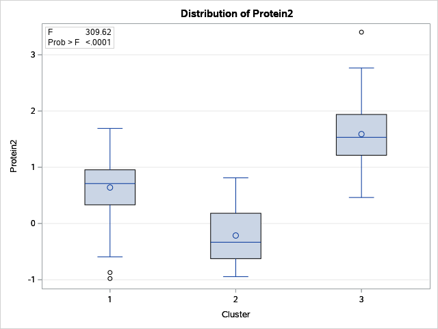

The GLM Procedure

| Class Level Information Class | Class Level Information Levels | Class Level Information Values |
| --- | --- | --- |
| CLUSTER | 3 | 1 2 3 |

| Number of Observations Read | 321 |
| --- | --- |
| Number of Observations Used | 321 |

The GLM Procedure

Dependent Variable: Protein3

| Source | DF | Sum of Squares | Mean Square | F Value | Pr > F |
| --- | --- | --- | --- | --- | --- |
| Model | 2 | 40.0495257 | 20.0247629 | 90.22 | <.0001 |
| Error | 318 | 70.5813076 | 0.2219538 |  |  |
| Corrected Total | 320 | 110.6308333 |  |  |  |

| R-Square | Coeff Var | Root MSE | Protein3 Mean |
| --- | --- | --- | --- |
| 0.362011 | -505.0677 | 0.471120 | -0.093279 |

| Source | DF | Type I SS | Mean Square | F Value | Pr > F |
| --- | --- | --- | --- | --- | --- |
| CLUSTER | 2 | 40.04952572 | 20.02476286 | 90.22 | <.0001 |

| Source | DF | Type III SS | Mean Square | F Value | Pr > F |
| --- | --- | --- | --- | --- | --- |
| CLUSTER | 2 | 40.04952572 | 20.02476286 | 90.22 | <.0001 |

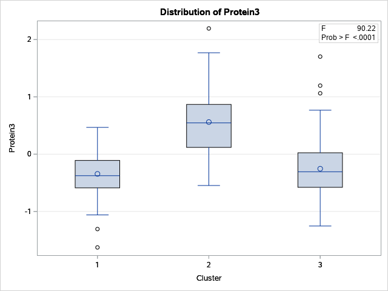

The GLM Procedure

| Class Level Information Class | Class Level Information Levels | Class Level Information Values |
| --- | --- | --- |
| CLUSTER | 3 | 1 2 3 |

| Number of Observations Read | 321 |
| --- | --- |
| Number of Observations Used | 321 |

The GLM Procedure

Dependent Variable: Protein4

| Source | DF | Sum of Squares | Mean Square | F Value | Pr > F |
| --- | --- | --- | --- | --- | --- |
| Model | 2 | 38.9342533 | 19.4671266 | 72.77 | <.0001 |
| Error | 318 | 85.0643342 | 0.2674979 |  |  |
| Corrected Total | 320 | 123.9985875 |  |  |  |

| R-Square | Coeff Var | Root MSE | Protein4 Mean |
| --- | --- | --- | --- |
| 0.313989 | 5868.760 | 0.517202 | 0.008813 |

| Source | DF | Type I SS | Mean Square | F Value | Pr > F |
| --- | --- | --- | --- | --- | --- |
| CLUSTER | 2 | 38.93425329 | 19.46712665 | 72.77 | <.0001 |

| Source | DF | Type III SS | Mean Square | F Value | Pr > F |
| --- | --- | --- | --- | --- | --- |
| CLUSTER | 2 | 38.93425329 | 19.46712665 | 72.77 | <.0001 |

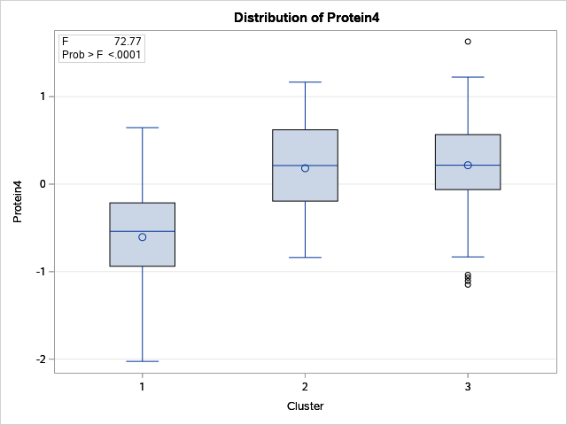